# Part I - Data Exploration of Loan Data from Prosper

#### **Question 11**: What was the distibution of loan listings amongst the different classes in `CreditGrade` & `LoanStatus` for each unique `EmploymentStatus` class?

##### **Visualisation**

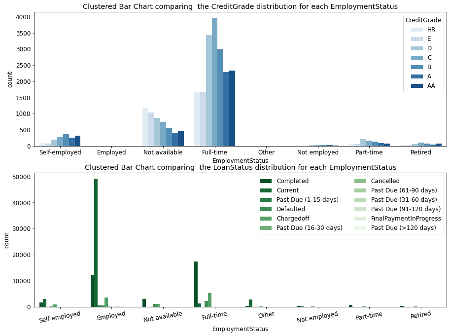

```python
plt.figure(figsize = [15, 11])

# subplot 1: Clustered Bar Chart of EmploymentStatus vs Credit Grade
plt.subplot(2, 1, 1)
plt.title("Clustered Bar Chart comparing  the CreditGrade distribution for each EmploymentStatus")
sb.countplot(data = loan_df, x = 'EmploymentStatus', hue = 'CreditGrade', palette = 'Blues');

# subplot 3: Prosper rating vs. employment status, use different color palette
ax = plt.subplot(2, 1, 2)
plt.title("Clustered Bar Chart comparing  the LoanStatus distribution for each EmploymentStatus")
sb.countplot(data = loan_df, x = 'EmploymentStatus', hue = 'LoanStatus', palette = 'Greens_r')
ax.legend(loc = 1, ncol = 2); # re-arrange legend to remove overlapping
plt.xticks(rotation=10);
```

##### 1. Frequency of loan listings by `EmploymentStatus` and `CreditGrade`.

From the top-most visualisation, we can derive that amongst full-time employees, the majority of this sample population were under `CreditGrade` **C**, followed by `CreditGrade` **D** then `CreditGrade` **B**. This illustrate that many of Prospers' borrowers who are employed full-time are often part of `CreditGrade` **D** and above(C, B, A, AA).

Amongst the population of self employed borrowers, majority of borrowers are part of `CreditGrade` **C** and above. For borrowers who did not provide their EmploymentStatus information, most of them were in the lower `CreditGrade` classes **HR, E and D**. The 'Employed' status has no values plotted in it which is rather strange and could mean missing `CreditGrade` values for the 'Employed' `Employment Status`.

##### 2. Frequency of loan listings by `EmploymentStatus` and `LoanStatus`.

This visualisation shows that amongst Employed borrowers, a great majority have active/Current Loans meaning their loans are active with the second-most populated category as Completed meaning borrowers had completed their loan payments. As for borrowers with Full-Time employment most of them had completed their Loan Payments with the second most populated group in this category(Full-Time borrowers) being those whose loans were CharedOff meaning the bank considered those loans uncollectable.

### Talk about some of the relationships you observed in this part of the investigation. How did the feature(s) of interest vary with other features in the dataset?

- An interesting trend was notted between the features' `BorrowerRate` & the borrowers' `CreditGrade` ranking. As a borrower's Credit Score increases from HR to AA their Loan's Interest Rates decreases. Another interesting observation noted on the `CreditGrade` column contained a lot of outliers as depicted in the second boxplot between `BorrowerRate` & `CreditGrade`.
- Positive Correlations were noted between `BorrowerAPR` & `BorrowerRate` as well as `BorrowerRate` & `Estimated returns`. This shows that as a Borrower'sLoan interest rate increases so does the Borrower's Annual Percentage rate and Estimated Returns from the loan.

## Multivariate Exploration

#### **Question 12**: How does a Borrower's ProsperRating influence their Borrower's Interest Rates and Borrower's annual percentage rates?

#### **Visualisation**

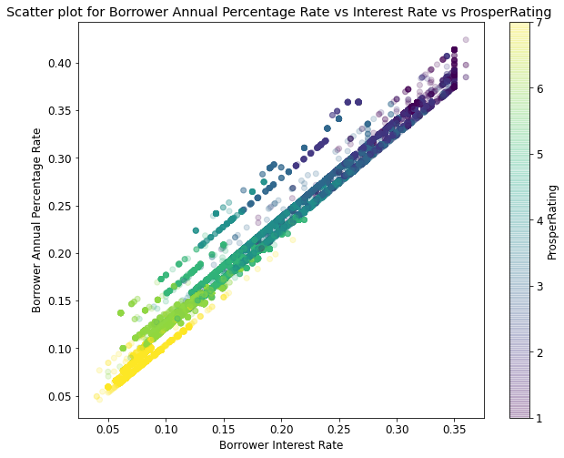

```python
# Comparing How interest rates are impacted based on a borrower's ProsperCedit Rating.
plt.figure(figsize = [10,8])
plt.scatter(data = loan_df, x = 'BorrowerRate', y = 'BorrowerAPR',
            c = 'ProsperRating', alpha=1/5)
plt.colorbar(label = 'ProsperRating')
plt.title("Scatter plot for Borrower Annual Percentage Rate vs Interest Rate vs ProsperRating ")
plt.xlabel('Borrower Interest Rate')
plt.ylabel('Borrower Annual Percentage Rate');
```

#### **Question 13**: How do Borrower's Interest Rate(`BorrowerRate`) and `IncomeRange` relate for the different Borrower's Credit Scores?

#### **Visualisation**

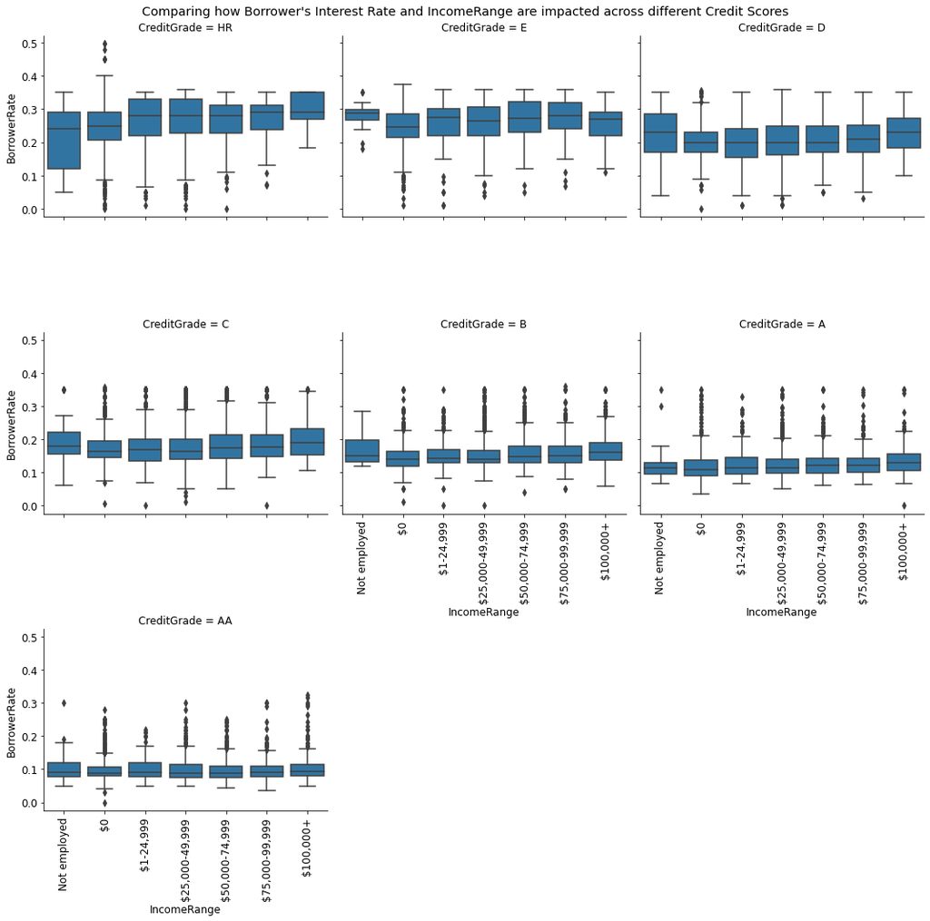

```python
# Subset Loan Data Across the different CreditGrade scores
g = sb.FacetGrid(data = loan_df, col = 'CreditGrade', height = 4, col_wrap=3);
g.fig.set_size_inches(15,15)
g.fig.suptitle("Comparing how Borrower's Interest Rate and IncomeRange are impacted across different Credit Scores")
[plt.setp(ax.get_xticklabels(), rotation=90) for ax in g.axes.flat]
g.map(sb.boxplot, 'IncomeRange', 'BorrowerRate');
```